# Loan Analysis

## Important – Read This First!"

If you cloned this notebook from GitHub, you will need to either  
1. Download the *loan.csv* file from Kaggle (link given under Datasets) or  
2. Unzip the *LCloan.csv.bz3* from the data folder.

If you download from Kaggle, you will need to rename *loan.csv* to *LCloan.csv* and save it in the data folder.

# Introduction

### Loan Analysis using Lending Club Data

**Keywords**: Lending Club, loan analysis, exploratory data analysis, correlation analysis

In this notebook we review some steps in loan analysis, specifically exploratory analysis. To do this we employ several ways to visualize the data. This includes:

- Correlation plots
- Histograms
- Five-number summaries and Boxplots

This work uses historical data from [Lending Club](https://www.kaggle.com/wendykan/lending-club-loan-data) for period from 2007 until 2015.

#### About Lending Club

The [Lending Club](https://www.lendingclub.com/) is an online marketplace for personal loans that matches borrowers who are seeking a loan with investors looking to lend money and make a return. Each borrower fills out a comprehensive application, providing their past financial history, the reason for the loan, and more. Lending Club evaluates each borrower’s credit score using past historical data and assigns an interest rate to the borrower.

The benefit to us is that some of these data have been made available to us for analysis. While loan data excludes personally identifiable information, it does include attributes like FICO score, location, annual income, lines of credit, and descriptions of why the applicant needs the loan.

# Datasets

There are several sources of Lending Club data that you might be able to use to test the code:

- [Kaggle option 1](https://www.kaggle.com/wendykan/lending-club-loan-data)
- [Kaggle option 2](https://www.kaggle.com/wordsforthewise/lending-club)
- [Data World](https://data.world/jaypeedevlin/lending-club-loan-data-2007-11) (data from 2007)
- [Lending Club](https://www.lendingclub.com/auth/login?login_url=%2Finfo%2Fdownload-data.action)

Here we use the first Kaggle dataset (option 1).

These data contain complete loan data for all loans issued through the 2007-2015, including the current loan status (Current, Late, Fully Paid, etc.) and latest payment information. The file containing loan data through the “present” contains complete loan data for all loans issued through the previous completed calendar quarter. Additional features include credit scores, number of finance inquiries, address including zip codes, and state, and collections among others. A data dictionary is provided in a separate file.

# Sections

1. Setting up
2. Exploratory Analysis
   - Numeric Variable Analysis
   - Categorical Variable Analysis
   - Correlation Analysis

**Hint**: To excute code chunks, click the *Run* button within the chunk or place your cursor inside it and pressing *Ctrl+Shift+Enter*.

# Setting up

```r
# define used libraries
libraries_used <-
  c("lazyeval", "readr","plyr" ,"dplyr", "readxl", "ggplot2",
    "funModeling", "scales", "tidyverse", "corrplot", "GGally", "caret",
    "rpart", "randomForest", "pROC", "gbm", "choroplethr", "choroplethrMaps",
    "microbenchmark", "doParallel", "e1071", "data.table", "Hmisc",
    "PerformanceAnalytics")

## Uncomment below if you think you need packages installed
# # check missing libraries
# libraries_missing <-
#   libraries_used[!(libraries_used %in% installed.packages()[,"Package"])]
# # install missing libraries
# if(length(libraries_missing)) install.packages(libraries_missing, dependencies = TRUE)
```

```r
# load libraries
lapply(libraries_used, require, character.only = TRUE)
```

```
## funModeling v.1.9.3 :)
## Examples and tutorials at livebook.datascienceheroes.com
##  / Now in Spanish: librovivodecienciadedatos.ai
```

[output not shown]

[output cut: 16 more lines]

[output not shown]

```r
# Import data
loans <- fread("./data/LCloan.csv")
colnames(loans)
```

```
##   [1] "id"
##   [2] "member_id"
##   [3] "loan_amnt"
##   [4] "funded_amnt"
##   [5] "funded_amnt_inv"
##   [6] "term"
##   [7] "int_rate"
##   [8] "installment"
##   [9] "grade"
##  [10] "sub_grade"
##  [11] "emp_title"
##  [12] "emp_length"
##  [13] "home_ownership"
##  [14] "annual_inc"
##  [15] "verification_status"
```

[output cut: 130 more lines]

```r
dim(loans)
```

```
## [1] 2260668     145
```

# Exploratory Analysis

### Numeric Variable Analysis

Let’s build histograms for some of the numeric attributes in our dataset: - Annual Income (annual_inc) - Installment (installment) - Loan Interest Rates (int_rate) - Loan Amounts (loan_amnt) - Open Credit Line Accounts (open_acc) - Total Paid (tot_paid)

Let’s start with **Annual Income**. We’ll look first at a summary of the incomes.

```r
summary(loans$annual_inc)
```

```
##      Min.   1st Qu.    Median      Mean   3rd Qu.      Max.      NA's
##         0     46000     65000     77992     93000 110000000         4
```

We see there are NA’s. Let’s save loans to a new data frame: loans.nona. We’ll remove the NA’s for just annual income since that’s the variable we’re looking at now.

Reference: [Filter NAs](https://blog.exploratory.io/filter-data-with-dplyr-76cf5f1a258e)

Reference: [Delete columns with only NAs](https://stackoverflow.com/questions/15968494/how-to-delete-columns-that-contain-only-nas)

Reference: [Remove columns with some NAs](https://stackoverflow.com/questions/12454487/remove-columns-from-dataframe-where-some-of-values-are-na)

Reference: [Drop NAs with tidyverse](https://stackoverflow.com/questions/48658832/how-to-remove-row-if-it-has-a-na-value-in-one-certain-column)

Reference: [Conditional Statements](https://mgimond.github.io/ES218/Week03a.html#conditional_statements)

```r
loans.nona <- loans %>% filter(!is.na(annual_inc))
summary(loans.nona$annual_inc)
```

```
##      Min.   1st Qu.    Median      Mean   3rd Qu.      Max.
##         0     46000     65000     77992     93000 110000000
```

OK. NA’s are removed. Now let’s look at the Max and Min. We see a huge spread. Let’s take anything > $200,000 and set it to 200,000 so we can make the histogram work.

Reference: [If_Else](https://blog.rstudio.com/2016/06/27/dplyr-0-5-0/)

```r
loans.nona$annual_inc <- if_else(loans.nona$annual_inc > 200000, 200000,
                  loans.nona$annual_inc)

#Check that maximum $ was reset to 200000
loans.nona %>% summarise(min_inc = min(annual_inc),
                                    max_inc=max(annual_inc))
```

| min_inc | max_inc |
| --- | --- |
| 0 | 2e+05 |

Do same for minimum income

```r
summary(loans.nona$annual_inc[loans.nona$annual_inc > 0])
```

```
##      Min.   1st Qu.    Median      Mean   3rd Qu.      Max.
##      0.36  46000.00  65000.00  75083.46  93000.00 200000.00
```

```r
summary(loans.nona$annual_inc[loans.nona$annual_inc > 100])
```

```
##    Min. 1st Qu.  Median    Mean 3rd Qu.    Max.
##     115   46000   65000   75086   93000  200000
```

```r
summary(loans.nona$annual_inc[loans.nona$annual_inc > 1000])
```

```
##    Min. 1st Qu.  Median    Mean 3rd Qu.    Max.
##    1008   46000   65000   75091   93000  200000
```

Let’s set any income < $1000 to 1000

```r
loans.nona$annual_inc <- if_else(loans.nona$annual_inc < 1000, 1000,
                  loans.nona$annual_inc)

#Check that maximum $ was reset to 200000
loans.nona %>% summarise(min_inc = min(annual_inc),
                                    max_inc=max(annual_inc))
```

| min_inc | max_inc |
| --- | --- |
| 1000 | 2e+05 |

Now we build our histogram

Reference: [ggplot](http://www.sthda.com/english/wiki/ggplot2-title-main-axis-and-legend-titles)

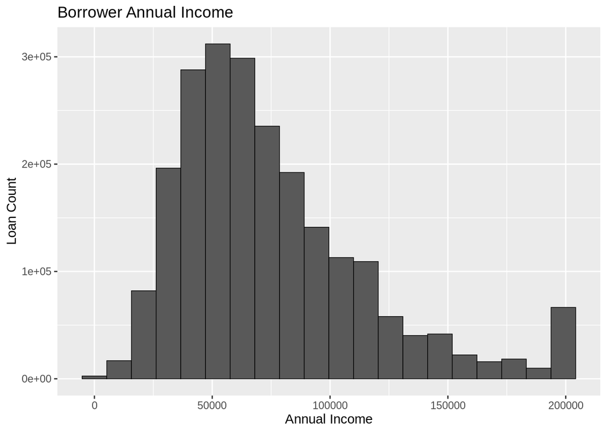

```r
ggplot(loans.nona, aes(x=annual_inc)) + geom_histogram(bins=20,
                                            colour='black', size=0.25) + ggtitle("Borrower Annual Income") + xlab("Annual Income") + ylab("Loan Count")
```

The distribution is right (positively) skewed. Most borrowers make less than $100,000 annually but we see there are some outliers with incomes greater than $200,000 annually

Repeat with next attribute: **Installment**

```r
summary(loans$installment)
```

```
##    Min. 1st Qu.  Median    Mean 3rd Qu.    Max.
##    4.93  251.65  377.99  445.81  593.32 1719.83
```

The spread looks okay and no NA’s so we can skip some of the steps needed for annual income and go straight to the historgram!

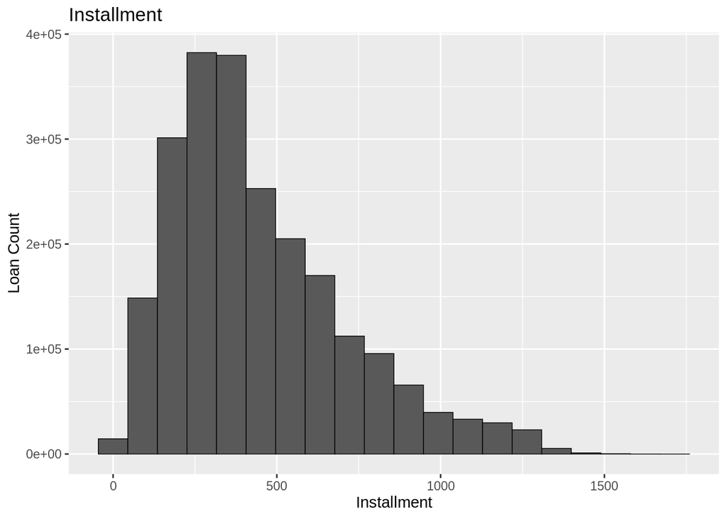

```r
ggplot(loans, aes(x=installment)) + geom_histogram(bins=20,
                                            colour='black', size=0.25) + ggtitle("Installment") + xlab("Installment") + ylab("Loan Count")
```

Repeat with next attribute: **Loan Interest Rates**

```r
summary(loans$int_rate)
```

```
##    Min. 1st Qu.  Median    Mean 3rd Qu.    Max.
##    5.31    9.49   12.62   13.09   15.99   30.99
```

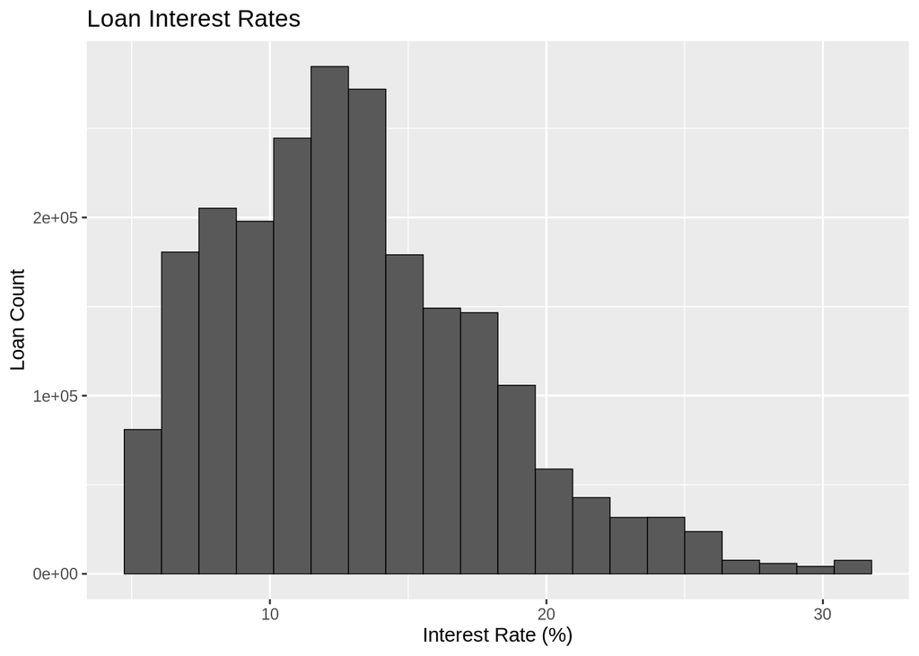

```r
ggplot(loans, aes(x=int_rate)) + geom_histogram(bins=20,
                                            colour='black', size=0.25) + ggtitle("Loan Interest Rates") + xlab("Interest Rate (%)") + ylab("Loan Count")
```

**Loan amounts**

```r
summary(loans$loan_amnt)
```

```
##    Min. 1st Qu.  Median    Mean 3rd Qu.    Max.
##     500    8000   12900   15047   20000   40000
```

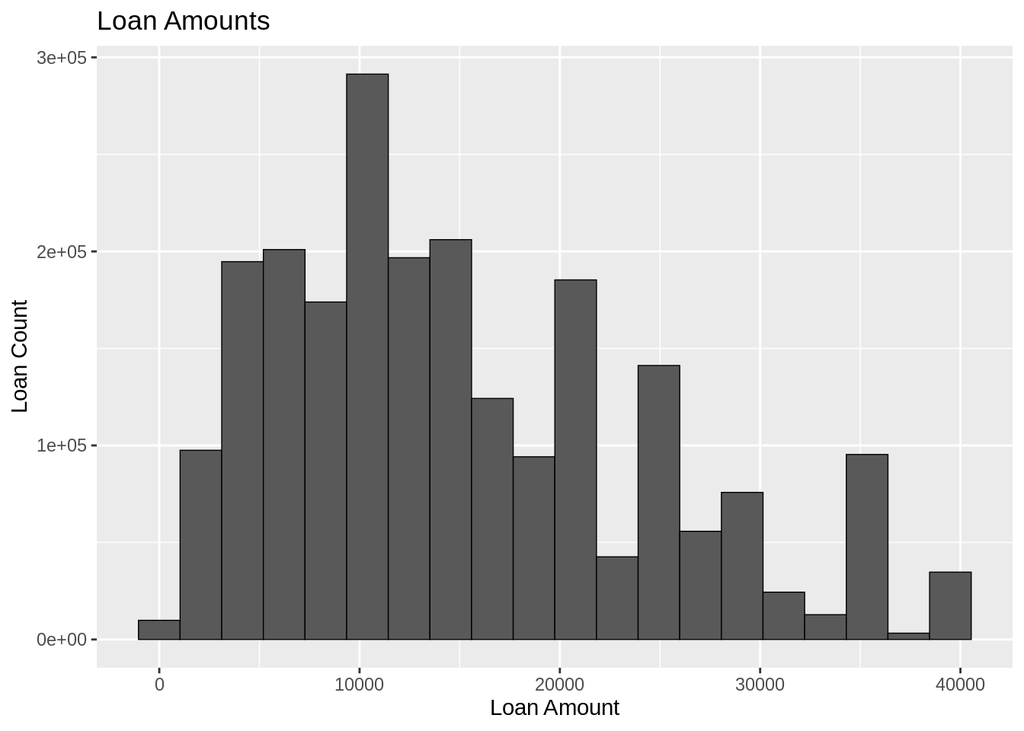

```r
ggplot(loans, aes(x=loan_amnt)) + geom_histogram(bins=20,
                                            colour='black', size=0.25) + ggtitle("Loan Amounts") + xlab("Loan Amount") + ylab("Loan Count")
```

**Open Credit Line Accounts**

Reference: [setting y limits](https://stackoverflow.com/questions/32505298/explain-ggplot2-warning-removed-k-rows-containing-missing-values)

Reference: [setting x limits](https://stackoverflow.com/questions/43475764/ggplot-non-finite-values-error)

Reference: [geom_bar warning](https://github.com/tidyverse/ggplot2/issues/2879)

```r
summary(loans$open_acc)
```

```
##    Min. 1st Qu.  Median    Mean 3rd Qu.    Max.    NA's
##    0.00    8.00   11.00   11.61   14.00  101.00      29
```

```r
# class(loans$open_acc)

#Remove NA's
loans.nona <- loans %>% filter(!is.na(open_acc))

#Condense max
loans.nona$open_acc <- if_else(as.numeric(loans.nona$open_acc) > 50, 50,
                  as.numeric(loans.nona$open_acc))

#Check that maximum was reset to 50
loans.nona %>% summarise(min_open = min(open_acc),
                                    max_open=max(open_acc))
```

| min_open | max_open |
| --- | --- |
| 0 | 50 |

```r
summary(loans.nona$open_acc)
```

```
##    Min. 1st Qu.  Median    Mean 3rd Qu.    Max.
##    0.00    8.00   11.00   11.61   14.00   50.00
```

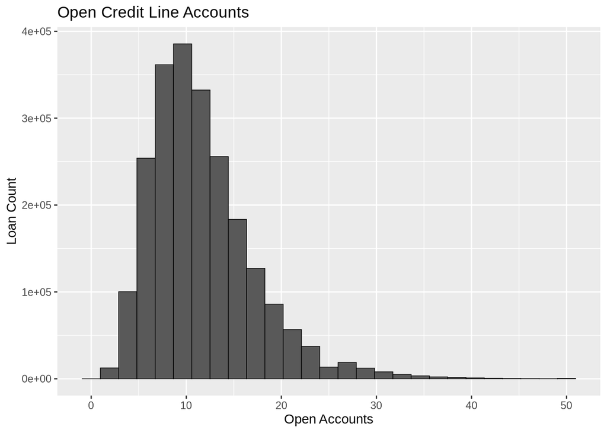

```r
ggplot(loans.nona, aes(x=open_acc)) + geom_histogram(bins=27,
                                            colour='black', size=0.25) +
  ggtitle("Open Credit Line Accounts") + xlab("Open Accounts") + ylab("Loan Count")
```

**Total Paid**

```r
summary(loans$total_pymnt)
```

```
##    Min. 1st Qu.  Median    Mean 3rd Qu.    Max.
##       0    4273    9061   11824   16708   63297
```

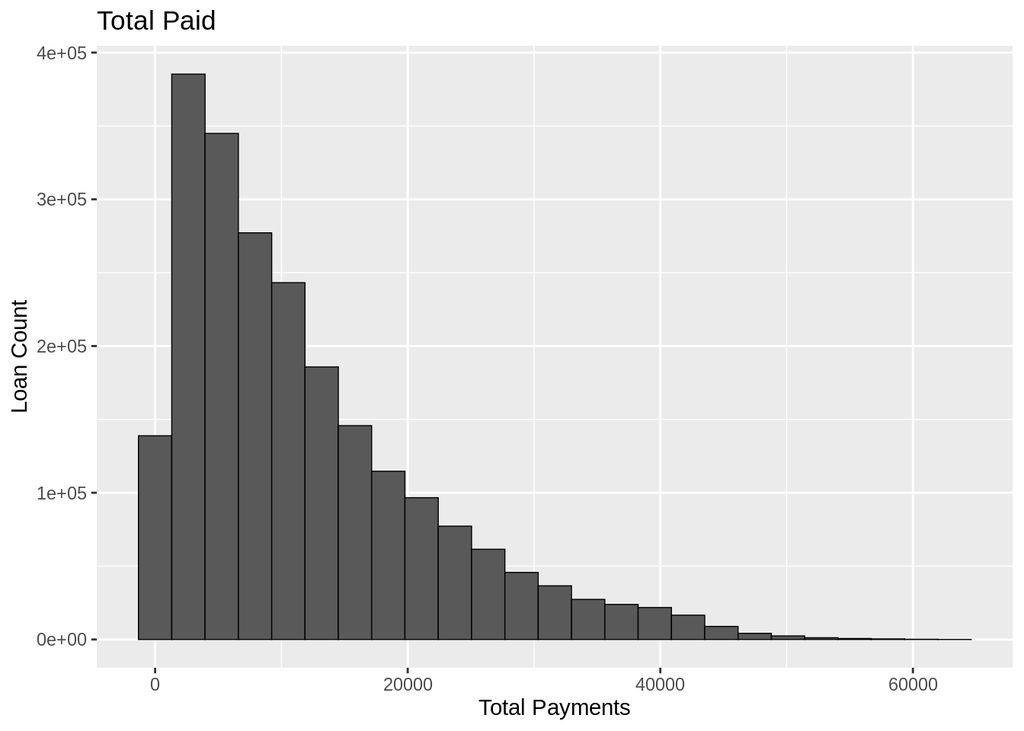

```r
ggplot(loans, aes(x=total_pymnt)) + geom_histogram(bins=25,
                                            colour='black', size=0.25) + ggtitle("Total Paid") + xlab("Total Payments") + ylab("Loan Count")
```

Conclusion: Most of our distributions are right or positively skewed. Respective to a majority of variables in our dataset, it makes sense that these observations have a greater mean than median.

### Categorical Variable Analysis

Let’s build boxplots for some of the categorical attributes in our dataset: - Total paid by purpose (total_pymnt, purpose) - Loan amount by purpose (loam_amnt, purpose) - Total paid by loan grade (total_pymnt, grade) - Total paid by employment length (total_pymnt, emp_length ) - Total paid by loan status (total_pymnt, loan_status)

**Total paid by purpose**

Let’s look at what the different categories (purposes) for the loans are

```r
unique(loans$purpose)
```

```
##  [1] "debt_consolidation" "credit_card"        "house"
##  [4] "car"                "other"              "vacation"
##  [7] "home_improvement"   "small_business"     "major_purchase"
## [10] "medical"            "renewable_energy"   "moving"
## [13] "wedding"            "educational"
```

Now for a boxplot using ggplot

Reference: [ggplot boxplots](https://stackoverflow.com/questions/20841733/ggplot2-boxplot-only-shows-flat-lines)

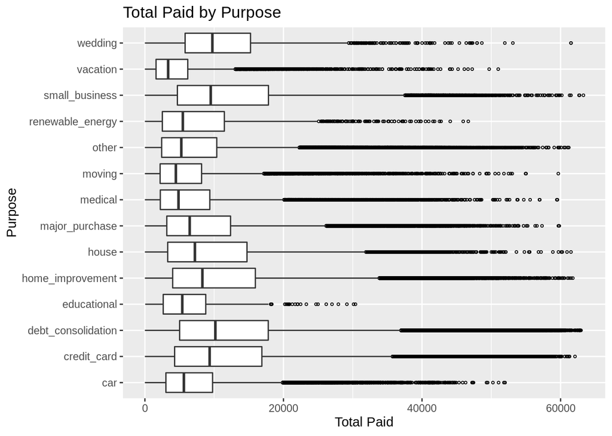

```r
ggplot(loans, aes(y=total_pymnt, x=purpose)) +
  geom_boxplot(outlier.colour="black", outlier.shape=1,
                outlier.size=0.7) + coord_flip() + ylab("Total Paid") +
  xlab("Purpose") + ggtitle("Total Paid by Purpose")
```

**Loan amount by purpose**

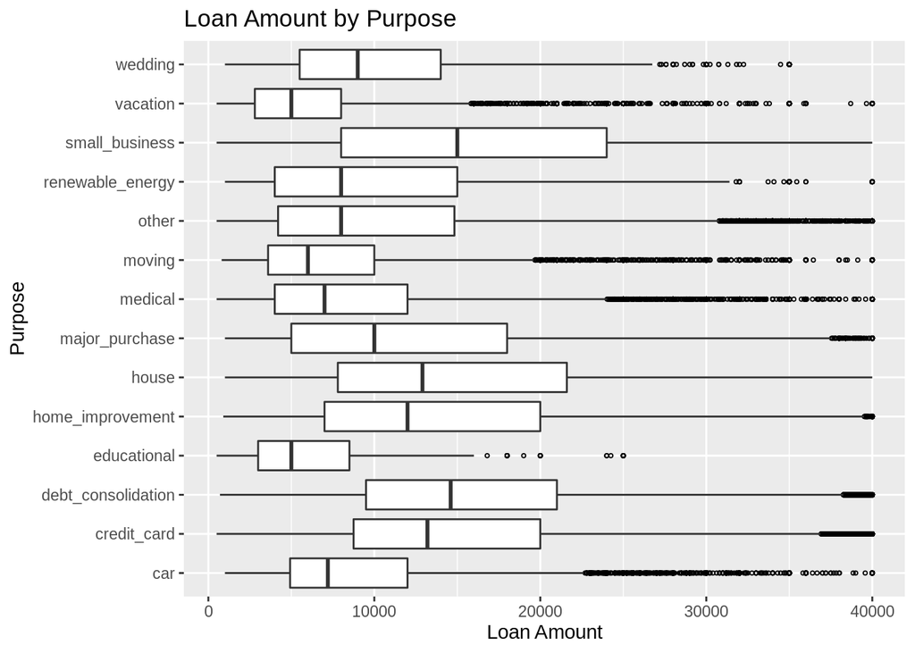

```r
ggplot(loans, aes(y=loan_amnt, x=purpose)) +
  geom_boxplot(outlier.colour="black", outlier.shape=1,
                outlier.size=0.7) + coord_flip() + ylab("Loan Amount") +
  xlab("Purpose") + ggtitle("Loan Amount by Purpose")
```

**Total paid by loan grade**

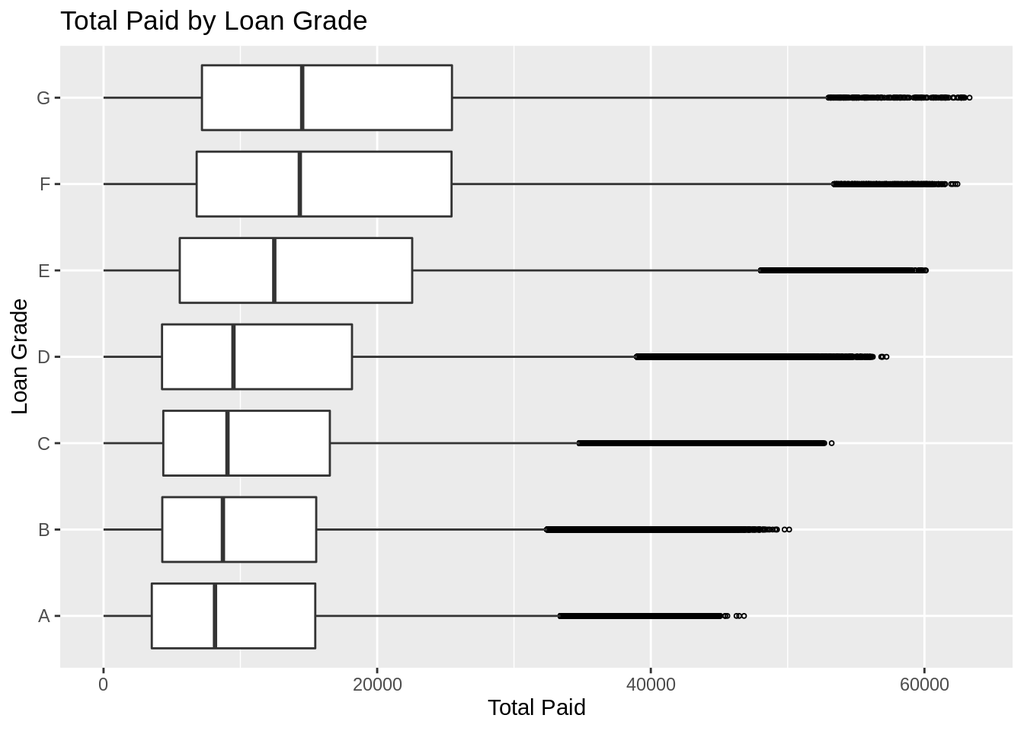

```r
ggplot(loans, aes(y=total_pymnt, x=grade)) +
  geom_boxplot(outlier.colour="black", outlier.shape=1,
                outlier.size=0.7) + coord_flip() + ylab("Total Paid") +
  xlab("Loan Grade") + ggtitle("Total Paid by Loan Grade")
```

**Total paid by employment length**

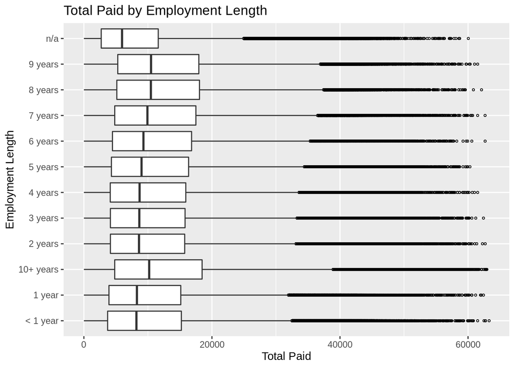

```r
ggplot(loans, aes(y=total_pymnt, x=emp_length)) +
  geom_boxplot(outlier.colour="black", outlier.shape=1,
                outlier.size=0.7) + coord_flip() + ylab("Total Paid") +
  xlab("Employment Length") + ggtitle("Total Paid by Employment Length")
```

**Total paid by loan status**

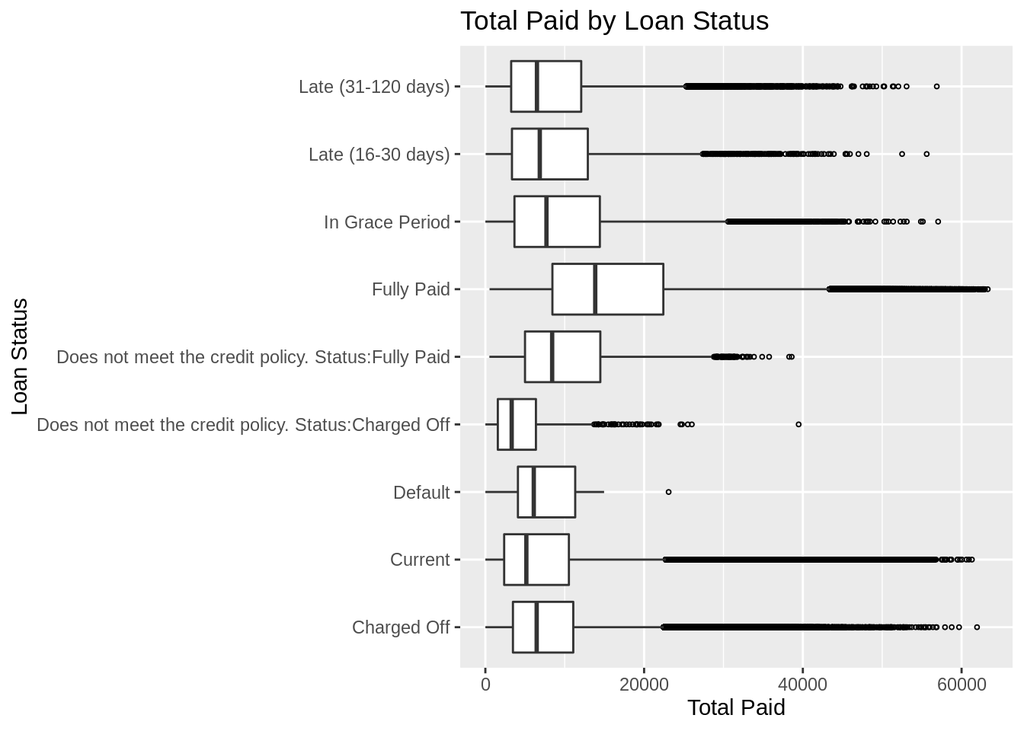

```r
ggplot(loans, aes(y=total_pymnt, x=loan_status)) +
  geom_boxplot(outlier.colour="black", outlier.shape=1,
                outlier.size=0.7) + coord_flip() + ylab("Total Paid") +
  xlab("Loan Status") + ggtitle("Total Paid by Loan Status")
```

**Bonus** You can reduce the number of categories in purpose to bucket things a bit

```r
loans.reduc <- loans
```

```r
# reduce the number of categories of purpose
loans.reduc <- mutate(loans.reduc, purpose_new =
                       ifelse(purpose == "credit_card" |
                              purpose == "debt_consolidation", "debt",
                       ifelse(purpose == "car" |
                              purpose == "major_purchase" |
                              purpose == "vacation" |
                              purpose == "wedding" |
                              purpose == "medical" |
                              purpose == "other", "purchase",
                       ifelse(purpose == "house" |
                              purpose == "home_improvement" |
                              purpose == "moving" |
                              purpose == "renewable_energy", "home_imprv",
                       purpose))))
```

```r
unique(loans.reduc$purpose_new)
```

```
## [1] "debt"           "home_imprv"     "purchase"       "small_business"
## [5] "educational"
```

**Bonus** You can also use boxplot instead of ggplot

Reference: [boxplots for credit modeling](https://datascienceplus.com/visualizations-for-credit-modeling-in-r/)

Reference: [boxplot tutorial](https://www.r-bloggers.com/box-plot-with-r-tutorial/)

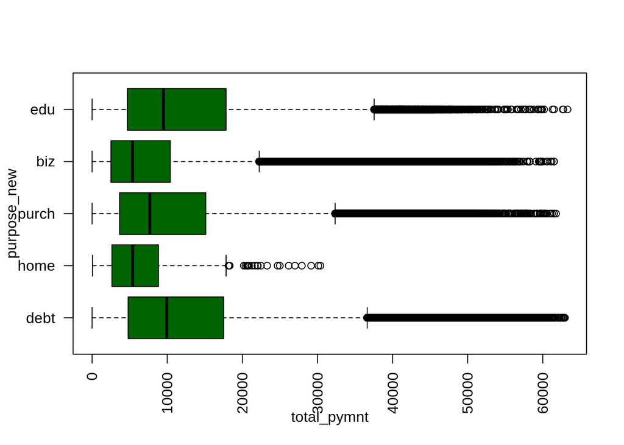

```r
# Box plot interest rate & purpose
boxplot(total_pymnt ~ purpose_new, col="darkgreen", horizontal=T, names = c(
  "debt", "home", "purch", "biz", "edu"), las=2, data=loans.reduc)
```

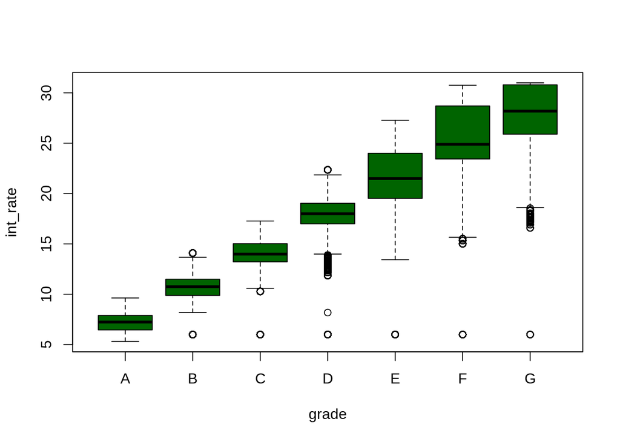

```r
# Boxplot interest rate & grade
boxplot(int_rate ~ grade, col="darkgreen", horizontal=F, data=loans)
```

### Correlation Analysis

There are different ways to visualize correlation. Below are some examples.

```r
# look at numeric variables
num_vars <-
  loans %>%
  select_if(is.numeric) %>%
  names()

num_vars %>% knitr::kable()
```

| x |
| --- |
| loan_amnt |
| funded_amnt |
| funded_amnt_inv |
| int_rate |
| installment |
| annual_inc |
| dti |
| delinq_2yrs |
| inq_last_6mths |
| mths_since_last_delinq |
| mths_since_last_record |
| open_acc |
| pub_rec |
| revol_bal |
| revol_util |
| total_acc |
| out_prncp |
| out_prncp_inv |
| total_pymnt |
| total_pymnt_inv |
| total_rec_prncp |
| total_rec_int |
| total_rec_late_fee |
| recoveries |
| collection_recovery_fee |
| last_pymnt_amnt |
| collections_12_mths_ex_med |
| mths_since_last_major_derog |
| policy_code |
| annual_inc_joint |

[output cut: 76 more lines]

```r
loans.num <- loans %>% select(num_vars)
```

The function `funModeling::df_status()` has parameter `print_results = TRUE` set by default which means the data will be assigned and printed at the same time.

```r
meta_loans <- funModeling::df_status(loans.num, print_results = FALSE)
knitr::kable(meta_loans)
```

| variable | q_zeros | p_zeros | q_na | p_na | q_inf | p_inf | type | unique |
| --- | --- | --- | --- | --- | --- | --- | --- | --- |
| loan_amnt | 0 | 0.00 | 0 | 0.00 | 0 | 0 | integer | 1572 |
| funded_amnt | 0 | 0.00 | 0 | 0.00 | 0 | 0 | integer | 1572 |
| funded_amnt_inv | 233 | 0.01 | 0 | 0.00 | 0 | 0 | numeric | 10058 |
| int_rate | 0 | 0.00 | 0 | 0.00 | 0 | 0 | numeric | 673 |
| installment | 0 | 0.00 | 0 | 0.00 | 0 | 0 | numeric | 93296 |
| annual_inc | 1667 | 0.07 | 4 | 0.00 | 0 | 0 | numeric | 89368 |
| dti | 1732 | 0.08 | 1711 | 0.08 | 0 | 0 | numeric | 10845 |
| delinq_2yrs | 1839108 | 81.35 | 29 | 0.00 | 0 | 0 | integer | 37 |
| inq_last_6mths | 1381722 | 61.12 | 30 | 0.00 | 0 | 0 | integer | 28 |
| mths_since_last_delinq | 2637 | 0.12 | 1158502 | 51.25 | 0 | 0 | integer | 173 |
| mths_since_last_record | 1296 | 0.06 | 1901512 | 84.11 | 0 | 0 | integer | 129 |
| open_acc | 56 | 0.00 | 29 | 0.00 | 0 | 0 | integer | 91 |
| pub_rec | 1902758 | 84.17 | 29 | 0.00 | 0 | 0 | integer | 43 |
| revol_bal | 12562 | 0.56 | 0 | 0.00 | 0 | 0 | integer | 102251 |
| revol_util | 13069 | 0.58 | 1802 | 0.08 | 0 | 0 | numeric | 1430 |
| total_acc | 0 | 0.00 | 29 | 0.00 | 0 | 0 | integer | 152 |
| out_prncp | 1312200 | 58.04 | 0 | 0.00 | 0 | 0 | numeric | 364399 |
| out_prncp_inv | 1312200 | 58.04 | 0 | 0.00 | 0 | 0 | numeric | 377353 |
| total_pymnt | 1008 | 0.04 | 0 | 0.00 | 0 | 0 | numeric | 1608698 |
| total_pymnt_inv | 1286 | 0.06 | 0 | 0.00 | 0 | 0 | numeric | 1299089 |
| total_rec_prncp | 2575 | 0.11 | 0 | 0.00 | 0 | 0 | numeric | 487427 |
| total_rec_int | 2657 | 0.12 | 0 | 0.00 | 0 | 0 | numeric | 629835 |
| total_rec_late_fee | 2176107 | 96.26 | 0 | 0.00 | 0 | 0 | numeric | 17991 |
| recoveries | 2083167 | 92.15 | 0 | 0.00 | 0 | 0 | numeric | 127920 |
| collection_recovery_fee | 2091587 | 92.52 | 0 | 0.00 | 0 | 0 | numeric | 140449 |
| last_pymnt_amnt | 2876 | 0.13 | 0 | 0.00 | 0 | 0 | numeric | 692560 |
| collections_12_mths_ex_med | 2223085 | 98.34 | 145 | 0.01 | 0 | 0 | integer | 16 |
| mths_since_last_major_derog | 375 | 0.02 | 1679893 | 74.31 | 0 | 0 | integer | 183 |
| policy_code | 0 | 0.00 | 0 | 0.00 | 0 | 0 | integer | 1 |
| annual_inc_joint | 0 | 0.00 | 2139958 | 94.66 | 0 | 0 | numeric | 17633 |

[output cut: 76 more lines]

Some variables have only one unique value, which are not useful for any analysis or model buidling.

For improved readability, we use the scales::percent() function to convert output to percent.

```r
meta_loans <-
  meta_loans %>%
  mutate(uniq_rat = unique / nrow(loans))

meta_loans %>%
  select(variable, unique, uniq_rat) %>%
  mutate(unique = unique, uniq_rat = scales::percent(uniq_rat)) %>%
  knitr::kable()
```

| variable | unique | uniq_rat |
| --- | --- | --- |
| loan_amnt | 1572 | 0% |
| funded_amnt | 1572 | 0% |
| funded_amnt_inv | 10058 | 0% |
| int_rate | 673 | 0% |
| installment | 93296 | 4% |
| annual_inc | 89368 | 4% |
| dti | 10845 | 0% |
| delinq_2yrs | 37 | 0% |
| inq_last_6mths | 28 | 0% |
| mths_since_last_delinq | 173 | 0% |
| mths_since_last_record | 129 | 0% |
| open_acc | 91 | 0% |
| pub_rec | 43 | 0% |
| revol_bal | 102251 | 5% |
| revol_util | 1430 | 0% |
| total_acc | 152 | 0% |
| out_prncp | 364399 | 16% |
| out_prncp_inv | 377353 | 17% |
| total_pymnt | 1608698 | 71% |
| total_pymnt_inv | 1299089 | 57% |
| total_rec_prncp | 487427 | 22% |
| total_rec_int | 629835 | 28% |
| total_rec_late_fee | 17991 | 1% |
| recoveries | 127920 | 6% |
| collection_recovery_fee | 140449 | 6% |
| last_pymnt_amnt | 692560 | 31% |
| collections_12_mths_ex_med | 16 | 0% |
| mths_since_last_major_derog | 183 | 0% |
| policy_code | 1 | 0% |
| annual_inc_joint | 17633 | 1% |

[output cut: 76 more lines]

```r
meta_loans <- funModeling::df_status(loans.num, print_results = FALSE)

meta_loans %>%
  select(variable, p_zeros, p_na, unique) %>%
  filter_(~ variable %in% num_vars) %>%
  knitr::kable()
```

| variable | p_zeros | p_na | unique |
| --- | --- | --- | --- |
| loan_amnt | 0.00 | 0.00 | 1572 |
| funded_amnt | 0.00 | 0.00 | 1572 |
| funded_amnt_inv | 0.01 | 0.00 | 10058 |
| int_rate | 0.00 | 0.00 | 673 |
| installment | 0.00 | 0.00 | 93296 |
| annual_inc | 0.07 | 0.00 | 89368 |
| dti | 0.08 | 0.08 | 10845 |
| delinq_2yrs | 81.35 | 0.00 | 37 |
| inq_last_6mths | 61.12 | 0.00 | 28 |
| mths_since_last_delinq | 0.12 | 51.25 | 173 |
| mths_since_last_record | 0.06 | 84.11 | 129 |
| open_acc | 0.00 | 0.00 | 91 |
| pub_rec | 84.17 | 0.00 | 43 |
| revol_bal | 0.56 | 0.00 | 102251 |
| revol_util | 0.58 | 0.08 | 1430 |
| total_acc | 0.00 | 0.00 | 152 |
| out_prncp | 58.04 | 0.00 | 364399 |
| out_prncp_inv | 58.04 | 0.00 | 377353 |
| total_pymnt | 0.04 | 0.00 | 1608698 |
| total_pymnt_inv | 0.06 | 0.00 | 1299089 |
| total_rec_prncp | 0.11 | 0.00 | 487427 |
| total_rec_int | 0.12 | 0.00 | 629835 |
| total_rec_late_fee | 96.26 | 0.00 | 17991 |
| recoveries | 92.15 | 0.00 | 127920 |
| collection_recovery_fee | 92.52 | 0.00 | 140449 |
| last_pymnt_amnt | 0.13 | 0.00 | 692560 |
| collections_12_mths_ex_med | 98.34 | 0.01 | 16 |
| mths_since_last_major_derog | 0.02 | 74.31 | 183 |
| policy_code | 0.00 | 0.00 | 1 |
| annual_inc_joint | 0.00 | 94.66 | 17633 |

[output cut: 76 more lines]

Let’s drop anything with NA’s more than 80% Let’s drop anything with zeros more than 80% Let’s drop anything with unique less than 1000

```r
meta_loans <- meta_loans %>% filter(p_na < 80 & p_zeros < 80 & unique > 1000)

meta_loans %>%
  select(variable, p_zeros, p_na, unique) %>%
  filter_(~ variable %in% num_vars) %>%
  knitr::kable()
```

| variable | p_zeros | p_na | unique |
| --- | --- | --- | --- |
| loan_amnt | 0.00 | 0.00 | 1572 |
| funded_amnt | 0.00 | 0.00 | 1572 |
| funded_amnt_inv | 0.01 | 0.00 | 10058 |
| installment | 0.00 | 0.00 | 93296 |
| annual_inc | 0.07 | 0.00 | 89368 |
| dti | 0.08 | 0.08 | 10845 |
| revol_bal | 0.56 | 0.00 | 102251 |
| revol_util | 0.58 | 0.08 | 1430 |
| out_prncp | 58.04 | 0.00 | 364399 |
| out_prncp_inv | 58.04 | 0.00 | 377353 |
| total_pymnt | 0.04 | 0.00 | 1608698 |
| total_pymnt_inv | 0.06 | 0.00 | 1299089 |
| total_rec_prncp | 0.11 | 0.00 | 487427 |
| total_rec_int | 0.12 | 0.00 | 629835 |
| last_pymnt_amnt | 0.13 | 0.00 | 692560 |
| tot_cur_bal | 0.04 | 3.11 | 487688 |
| total_bal_il | 7.02 | 38.31 | 162249 |
| max_bal_bc | 1.59 | 38.31 | 33726 |
| total_rev_hi_lim | 0.06 | 3.11 | 34220 |
| avg_cur_bal | 0.04 | 3.11 | 88597 |
| bc_open_to_buy | 1.36 | 3.31 | 91500 |
| bc_util | 1.23 | 3.36 | 1494 |
| tot_hi_cred_lim | 0.00 | 3.11 | 529972 |
| total_bal_ex_mort | 0.07 | 2.21 | 212777 |
| total_bc_limit | 1.12 | 2.21 | 20309 |
| total_il_high_credit_limit | 11.66 | 3.11 | 194137 |

```r
corr_vars <- dplyr::pull(meta_loans, variable)

corr_vars %>% knitr::kable()
```

| x |
| --- |
| loan_amnt |
| funded_amnt |
| funded_amnt_inv |
| installment |
| annual_inc |
| dti |
| revol_bal |
| revol_util |
| out_prncp |
| out_prncp_inv |
| total_pymnt |
| total_pymnt_inv |
| total_rec_prncp |
| total_rec_int |
| last_pymnt_amnt |
| tot_cur_bal |
| total_bal_il |
| max_bal_bc |
| total_rev_hi_lim |
| avg_cur_bal |
| bc_open_to_buy |
| bc_util |
| tot_hi_cred_lim |
| total_bal_ex_mort |
| total_bc_limit |
| total_il_high_credit_limit |

Reference: [correlation plot text size](https://stackoverflow.com/questions/5359619/r-change-size-of-axis-labels-for-corrplot)

```r
loans.corr <- loans %>% select(corr_vars)
dim(loans.corr)
```

```
## [1] 2260668      26
```

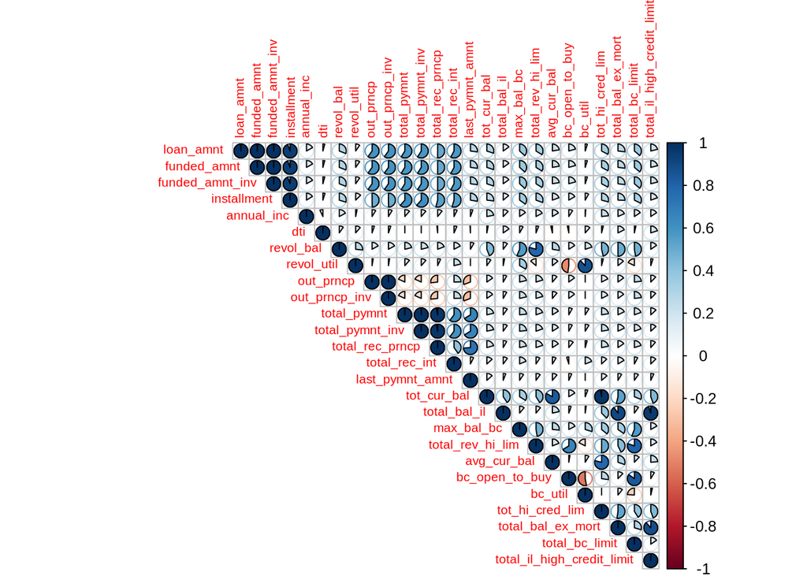

```r
LC <- cor(loans.corr, use = "complete.obs")

corrplot::corrplot(LC,
                   method = "pie", type = "upper",
                   tl.cex= 17/ncol(loans.corr))
```

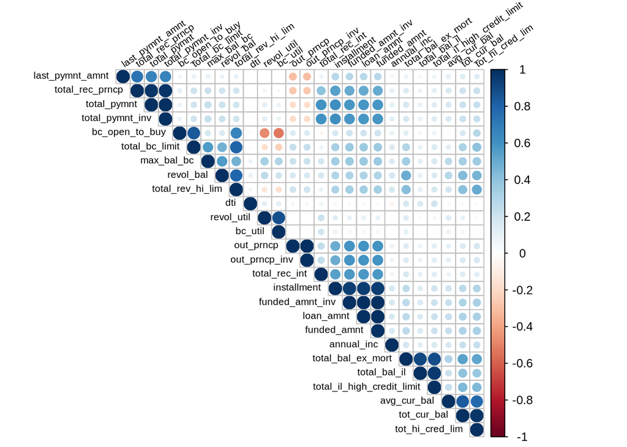

```r
corrplot(LC, type="upper", order="hclust",
         tl.col = "black", tl.srt = 35,
         tl.cex= 17/ncol(loans.corr))
```

```r
#round(LC, 2)
```

```r
LC2 <- rcorr(as.matrix(loans.corr))

#Extract the correlation coefficients
#LC2$r
```

```r
#extract p-values
#LC2$P
```

```r
# ++++++++++++++++++++++++++++
# flattenCorrMatrix
# ++++++++++++++++++++++++++++
# cormat : matrix of the correlation coefficients
# pmat : matrix of the correlation p-values
flattenCorrMatrix <- function(cormat, pmat) {
  ut <- upper.tri(cormat)
  data.frame(
    row = rownames(cormat)[row(cormat)[ut]],
    column = rownames(cormat)[col(cormat)[ut]],
    cor  =(cormat)[ut],
    p = pmat[ut]
    )
}


LC2<-rcorr(as.matrix(loans.corr[,1:7]))
flattenCorrMatrix(LC2$r, LC2$P)
```

| row | column | cor | p |
| --- | --- | --- | --- |
| loan_amnt | funded_amnt | 0.99975527 | 0 |
| loan_amnt | funded_amnt_inv | 0.99903791 | 0 |
| funded_amnt | funded_amnt_inv | 0.99934133 | 0 |
| loan_amnt | installment | 0.94562675 | 0 |
| funded_amnt | installment | 0.94596879 | 0 |
| funded_amnt_inv | installment | 0.94511931 | 0 |
| loan_amnt | annual_inc | 0.19724585 | 0 |
| funded_amnt | annual_inc | 0.19720738 | 0 |
| funded_amnt_inv | annual_inc | 0.19702503 | 0 |
| installment | annual_inc | 0.19026988 | 0 |

[output cut: 11 more lines]

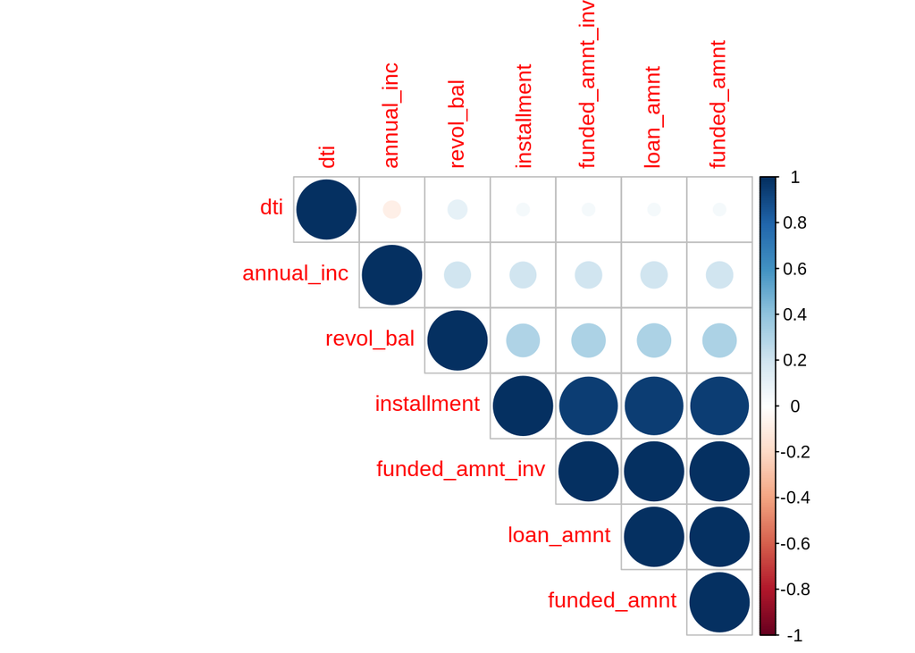

```r
corrplot(LC2$r, type="upper", order="hclust",
         p.mat = LC2$P, sig.level = 0.01, insig = "blank")
```

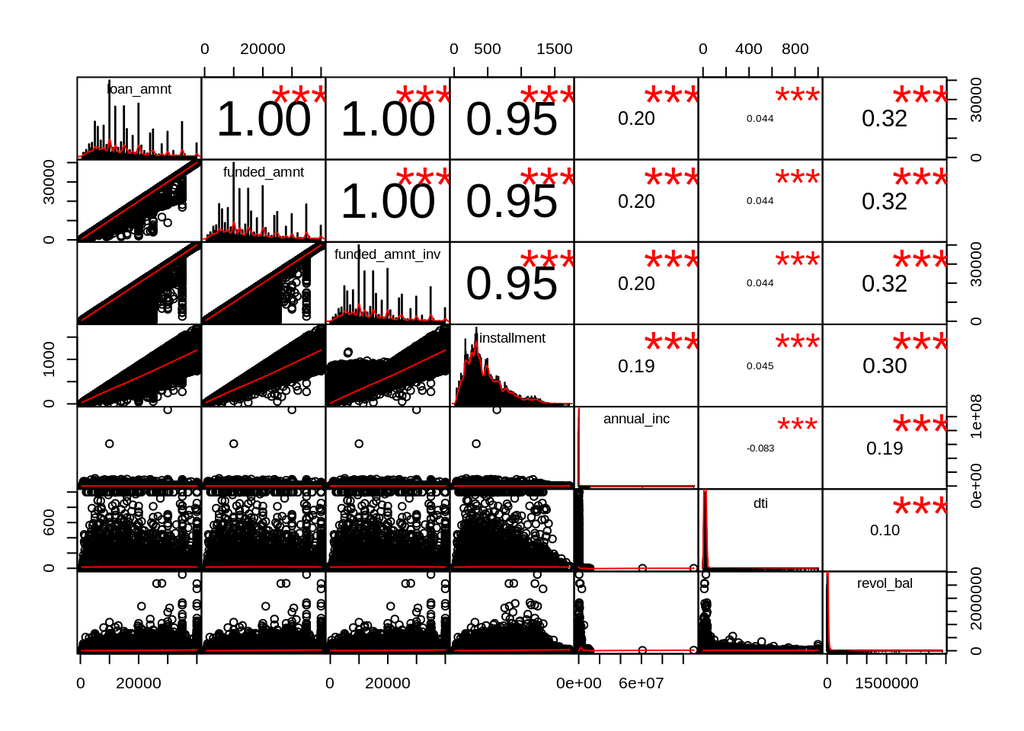

```r
#warning this will take awhile to run

chart.Correlation(loans.corr[,1:7], histogram=TRUE, pch=19)
```

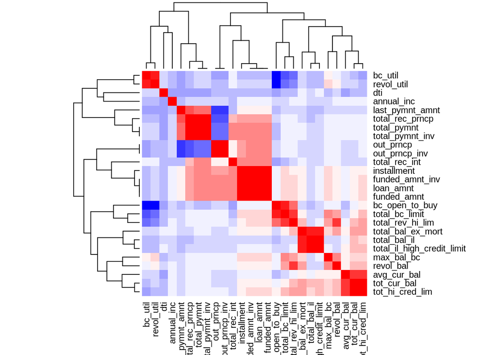

```r
col<- colorRampPalette(c("blue", "white", "red"))(20)
heatmap(x = LC, col = col, symm = TRUE)
```

Rather than a visual inspection, an (automatic) inspection of correlations and removal of highly correlated features can be done via function `caret::findCorrelation()` with a defined cutoff parameter.

```r
caret::findCorrelation(cor(loans.corr, use = "complete.obs"),
                       names = TRUE, cutoff = .5)
```

```
##  [1] "funded_amnt"                "loan_amnt"
##  [3] "funded_amnt_inv"            "installment"
##  [5] "total_pymnt_inv"            "total_pymnt"
##  [7] "tot_hi_cred_lim"            "tot_cur_bal"
##  [9] "total_rev_hi_lim"           "total_bal_ex_mort"
## [11] "total_bc_limit"             "revol_bal"
## [13] "out_prncp_inv"              "total_il_high_credit_limit"
## [15] "bc_open_to_buy"             "last_pymnt_amnt"
## [17] "revol_util"
```

Conclusion: Our correlation anlaysis indicates there is potential multicollinearity found between some of the independent variables. If multicollinearity is indeed detected as we conduct our models, then we will need to remove one of these variables.

Given above, we remove a few variables

```r
vars_to_remove <-
  c("funded_amnt" , "loan_amnt", "funded_amnt_inv", "installment",
    "total_pymnt_inv", "total_pymnt", "tot_hi_cred_lim", "tot_cur_bal",
    "total_rev_hi_lim", "total_bal_ex_mort",  "total_bc_limit",
    "revol_bal",  "out_prncp_inv", "total_il_high_credit_limit",
    "bc_open_to_buy",   "last_pymnt_amnt",  "revol_util"    )

train <- loans %>% select(-one_of(vars_to_remove))
```

Once you have a feel of the data, have your features selected, and the data cleaned, you can start to consider your modeling options.

### Notes on using R Notebook: